# Reporte_final_2021

Miguel Angel Martinez Rojas

11/13/2021

# Parte 2 de Reporte final

## Evaluación de sitios de unión a Lrp en *E. coli*

En primer lugar se guardó un objeto con los sitios de unión únicos previamente identificados, leyendo el archivo ordered_sites.txt

```r
library(dplyr)
```

```r
library(ggplot2)
sites <- read.delim(file="../results/ordered_sites.txt", header=FALSE)
colnames(sites) <- c("Start","Stop","Strand","Sequence")
```

Ahora se guardaron como objetos los datos de los archivos *sites.bed

```r
d69 <- read.delim(file="../data/GSE111874/DS00069/DS00069_sites.bed")
d70 <- read.delim(file="../data/GSE111874/DS00070/DS00070_sites.bed")
d71 <- read.delim(file="../data/GSE111874/DS00071/DS00071_sites.bed")
d72 <- read.delim(file="../data/GSE111874/DS00072/DS00072_sites.bed")
d73 <- read.delim(file="../data/GSE111874/DS00073/DS00073_sites.bed")
d74 <- read.delim(file="../data/GSE111874/DS00074/DS00074_sites.bed")
d75 <- read.delim(file="../data/GSE111874/DS00075/DS00075_sites.bed")
d76 <- read.delim(file="../data/GSE111874/DS00076/DS00076_sites.bed")
d77 <- read.delim(file="../data/GSE111874/DS00077/DS00077_sites.bed")
```

### Generación de data frames con argumentos lógicos de acuerdo al sitio de unión

Se guardaron objetos que contuvieran la valoración de la unión de Lrp al respectivo sitio reportado en cada una de las nueve condiciones estudiadas:

```r
df69 <- data.frame(condition_1=sites$Start %in% d69$start)
df70 <- data.frame(condition_2=sites$Start %in% d70$start)
df71 <- data.frame(condition_3=sites$Start %in% d71$start)
df72 <- data.frame(condition_4=sites$Start %in% d72$start)
df73 <- data.frame(condition_5=sites$Start %in% d73$start)
df74 <- data.frame(condition_6=sites$Start %in% d74$start)
df75 <- data.frame(condition_7=sites$Start %in% d75$start)
df76 <- data.frame(condition_8=sites$Start %in% d76$start)
df77 <- data.frame(condition_9=sites$Start %in% d77$start)
```

Creación de data frame indicando si el sitio específico se une a Lrp en cada condición:  
- Condición 1-3: Corresponde a medio mínimo + LIV  
- Condición 4-6: Corresponde a medio enriquecido  
- Condición 7-9: Corresponde a medio mínimo

```r
summary_Lrp <- cbind(sites,df69,df70,df71,df72,df73,df74,df75,df76,df77)

summary_Lrp
```

```
##      Start    Stop Strand      Sequence condition_1 condition_2 condition_3
## 1    84171   84184      + GATTATTATGCTG       FALSE        TRUE        TRUE
## 2    85373   85386      + GAATTTTATTCTG        TRUE        TRUE        TRUE
## 3   193488  193501      + GCTTTTTATTCTG       FALSE        TRUE       FALSE
## 4   344943  344956      + AGATATTATCCTG       FALSE       FALSE        TRUE
## 5   419323  419336      + GTGTTTTATACTG        TRUE        TRUE        TRUE
## 6   590710  590723      + GAATATTATCCGG       FALSE       FALSE       FALSE
## 7   605760  605773      - GATTTTTATGCTG       FALSE        TRUE        TRUE
## 8   662259  662272      + GAATTTTATCCTG       FALSE        TRUE       FALSE
## 9   754885  754898      - GGGTTTTATCCTG       FALSE       FALSE        TRUE
## 10  846510  846523      - GATTATTACCCTG       FALSE       FALSE       FALSE
## 11 1237383 1237396      + GAATTTTATGCTG        TRUE        TRUE        TRUE
## 12 1237528 1237541      + GATTATTATTCTT        TRUE        TRUE        TRUE
## 13 1297260 1297273      - GGATGTTATCCTG       FALSE        TRUE        TRUE
## 14 1772701 1772714      + GTATTTTATTCTT       FALSE       FALSE        TRUE
```

[output cut: 55 more lines]

Además, se crean objetos para comparar los sitios de unión de acuerdo con fases de crecimiento:  
- Condiciones 1, 4 y 7: Fase logarítmica  
- Condiciones 2, 5 y 8: Fase de transición  
- Condiciones 3, 6 y 9: Fase estacionaria

```r
logaritmic_phase <- cbind(sites,df69,df72,df75)

transition_phase <- cbind(sites,df70,df73,df76)

stationary_phase <- cbind(sites,df71,df74,df77)

logaritmic_phase
```

```
##      Start    Stop Strand      Sequence condition_1 condition_4 condition_7
## 1    84171   84184      + GATTATTATGCTG       FALSE        TRUE        TRUE
## 2    85373   85386      + GAATTTTATTCTG        TRUE        TRUE        TRUE
## 3   193488  193501      + GCTTTTTATTCTG       FALSE       FALSE       FALSE
## 4   344943  344956      + AGATATTATCCTG       FALSE       FALSE       FALSE
## 5   419323  419336      + GTGTTTTATACTG        TRUE        TRUE        TRUE
## 6   590710  590723      + GAATATTATCCGG       FALSE       FALSE       FALSE
## 7   605760  605773      - GATTTTTATGCTG       FALSE       FALSE       FALSE
## 8   662259  662272      + GAATTTTATCCTG       FALSE       FALSE       FALSE
## 9   754885  754898      - GGGTTTTATCCTG       FALSE       FALSE       FALSE
## 10  846510  846523      - GATTATTACCCTG       FALSE       FALSE       FALSE
## 11 1237383 1237396      + GAATTTTATGCTG        TRUE        TRUE        TRUE
## 12 1237528 1237541      + GATTATTATTCTT        TRUE        TRUE        TRUE
## 13 1297260 1297273      - GGATGTTATCCTG       FALSE       FALSE       FALSE
## 14 1772701 1772714      + GTATTTTATTCTT       FALSE       FALSE       FALSE
```

[output cut: 20 more lines]

```r
transition_phase
```

```
##      Start    Stop Strand      Sequence condition_2 condition_5 condition_8
## 1    84171   84184      + GATTATTATGCTG        TRUE        TRUE        TRUE
## 2    85373   85386      + GAATTTTATTCTG        TRUE        TRUE        TRUE
## 3   193488  193501      + GCTTTTTATTCTG        TRUE        TRUE       FALSE
## 4   344943  344956      + AGATATTATCCTG       FALSE       FALSE       FALSE
## 5   419323  419336      + GTGTTTTATACTG        TRUE        TRUE        TRUE
## 6   590710  590723      + GAATATTATCCGG       FALSE       FALSE        TRUE
## 7   605760  605773      - GATTTTTATGCTG        TRUE       FALSE       FALSE
## 8   662259  662272      + GAATTTTATCCTG        TRUE       FALSE       FALSE
## 9   754885  754898      - GGGTTTTATCCTG       FALSE       FALSE       FALSE
## 10  846510  846523      - GATTATTACCCTG       FALSE       FALSE        TRUE
## 11 1237383 1237396      + GAATTTTATGCTG        TRUE        TRUE        TRUE
## 12 1237528 1237541      + GATTATTATTCTT        TRUE        TRUE        TRUE
## 13 1297260 1297273      - GGATGTTATCCTG        TRUE       FALSE        TRUE
## 14 1772701 1772714      + GTATTTTATTCTT       FALSE       FALSE       FALSE
```

[output cut: 20 more lines]

```r
stationary_phase
```

```
##      Start    Stop Strand      Sequence condition_3 condition_6 condition_9
## 1    84171   84184      + GATTATTATGCTG        TRUE       FALSE        TRUE
## 2    85373   85386      + GAATTTTATTCTG        TRUE        TRUE        TRUE
## 3   193488  193501      + GCTTTTTATTCTG       FALSE       FALSE        TRUE
## 4   344943  344956      + AGATATTATCCTG        TRUE       FALSE       FALSE
## 5   419323  419336      + GTGTTTTATACTG        TRUE        TRUE        TRUE
## 6   590710  590723      + GAATATTATCCGG       FALSE       FALSE        TRUE
## 7   605760  605773      - GATTTTTATGCTG        TRUE       FALSE        TRUE
## 8   662259  662272      + GAATTTTATCCTG       FALSE       FALSE       FALSE
## 9   754885  754898      - GGGTTTTATCCTG        TRUE       FALSE        TRUE
## 10  846510  846523      - GATTATTACCCTG       FALSE       FALSE        TRUE
## 11 1237383 1237396      + GAATTTTATGCTG        TRUE        TRUE        TRUE
## 12 1237528 1237541      + GATTATTATTCTT        TRUE        TRUE        TRUE
## 13 1297260 1297273      - GGATGTTATCCTG        TRUE       FALSE        TRUE
## 14 1772701 1772714      + GTATTTTATTCTT        TRUE       FALSE       FALSE
```

[output cut: 20 more lines]

### Generación de resumen visual de la dinámica temporal en los sitios de unión de acuerdo con el medio.

Se decide crear una tabla que enliste el número de sitios de unión a Lrp donde las columnas sean las condiciones del medio, y las filas la fase de crecimiento. Para visualizar este comportamiento temporal de acuerdo a las condiciones nutricionales, se elabora un heatmap donde la fuente de variación se contrasta por columnas. Se permite la reordenación de columnas, encontrando cambios graduales de acuerdo con el enriquecimiento del medio Enriched>Mínimo+LIV>Mínimo.

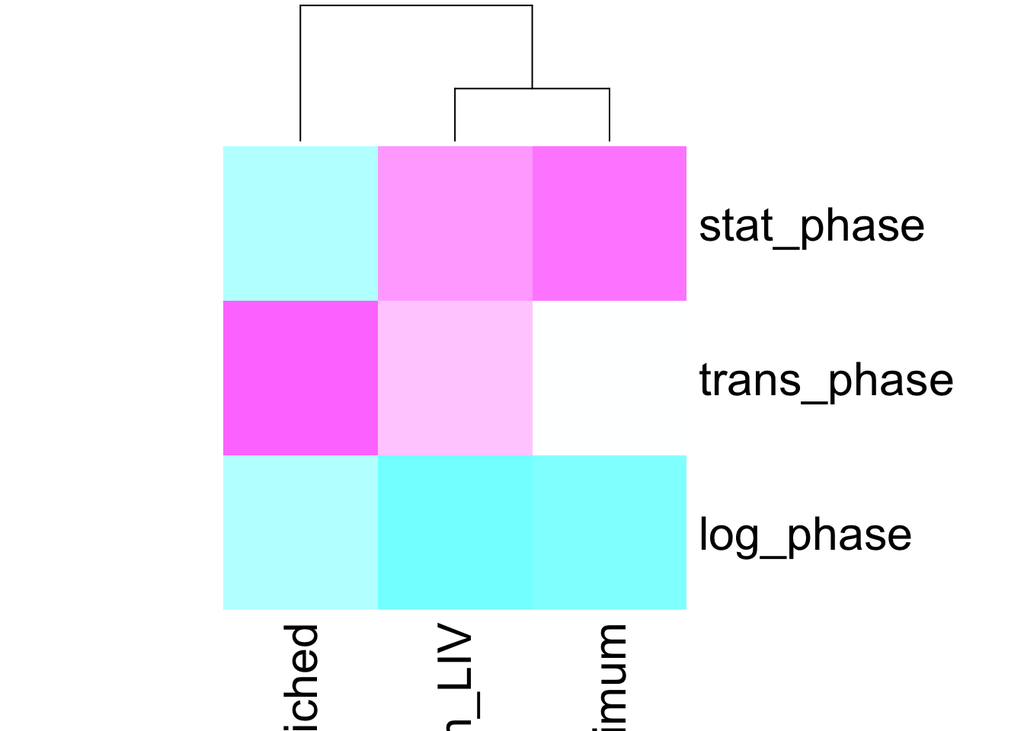

```r
log_phase <- data.frame(col1=count(filter(logaritmic_phase,logaritmic_phase$condition_1==TRUE)),col2=count(filter(logaritmic_phase,logaritmic_phase$condition_4==TRUE)),col3=count(filter(logaritmic_phase,logaritmic_phase$condition_7==TRUE)))

colnames(log_phase) <- c("Minimum_LIV","Enriched","Minimum")

trans_phase <- data.frame(col1=count(filter(transition_phase,transition_phase$condition_2==TRUE)),col2=count(filter(transition_phase,transition_phase$condition_5==TRUE)),col3=count(filter(transition_phase,transition_phase$condition_8==TRUE)))

colnames(trans_phase) <- c("Minimum_LIV","Enriched","Minimum")

stat_phase <- data.frame(col1=count(filter(stationary_phase,stationary_phase$condition_3==TRUE)),col2=count(filter(stationary_phase,stationary_phase$condition_6==TRUE)),col3=count(filter(stationary_phase,stationary_phase$condition_9==TRUE)))

colnames(stat_phase) <- c("Minimum_LIV","Enriched","Minimum")

Sites_dynamics <- rbind(log_phase,trans_phase,stat_phase)

rownames(Sites_dynamics) <- c("log_phase","trans_phase","stat_phase")

Sites_dynamics_matrix <- as.matrix(Sites_dynamics)

Temporal_Lrp_variation <- heatmap(Sites_dynamics_matrix, Rowv = NA, scale="column",col=cm.colors(256))
```

Las tablas relevantes se guardaron como archivo .Rdata en la carpeta de results, para poder cargarlos en futuras sesiones.

save(sites,summary_Lrp,logaritmic_phase,transition_phase,stationary_phase,Sites_dynamics,file=“Sites_per_condition.Rdata”)

load(“Sites_per_condition.Rdata”)

### Generación de data frames considerando la sensibilidad a los nutrientes del medio

Para responder con la interrogante inicial, y determinar si la unión de Lrp a cada uno de los distintos sitios cambia de acuerdo con las condiciones nutricionales del medio, se decide construir un data frame que incluya a los sitios de unión como filas, y la “sensibilidad al medio” en cada una de las tres fases de crecimiento como columnas. **El valor “Present” indica que la unión de Lrp a ese sitio cambia en al menos una de las tres condiciones nutricionales (en la fase de crecimiento correspondiente), mientras que el valor “Absent” indica que no hay cambios entre estas condiciones.** NOTA: Esta tabla no distingue si hay cambios en la unión que dependan de la fase de crecimiento en una condición nutricional particular.

```r
log_phase_same <- logaritmic_phase %>% filter(condition_1==condition_4) %>% filter(condition_4==condition_7)

log_phase_sorted <- data.frame(Change_log=ifelse(logaritmic_phase$Start %in% log_phase_same$Start, "Absent","Present"))

trans_phase_same <- transition_phase %>% filter(condition_2==condition_5) %>% filter(condition_5==condition_8)

trans_phase_sorted <- data.frame(Change_trans=ifelse(transition_phase$Start %in% trans_phase_same$Start, "Absent","Present"))

stat_phase_same <- stationary_phase %>% filter(condition_3==condition_6) %>% filter(condition_6==condition_9)

stat_phase_sorted <- data.frame(Change_stat=ifelse(stationary_phase$Start %in% stat_phase_same$Start, "Absent","Present"))

media_sensitivity <- cbind(sites,log_phase_sorted,trans_phase_sorted,stat_phase_sorted)

media_sensitivity
```

```
##      Start    Stop Strand      Sequence Change_log Change_trans Change_stat
## 1    84171   84184      + GATTATTATGCTG    Present       Absent     Present
## 2    85373   85386      + GAATTTTATTCTG     Absent       Absent      Absent
## 3   193488  193501      + GCTTTTTATTCTG     Absent      Present     Present
## 4   344943  344956      + AGATATTATCCTG     Absent       Absent     Present
## 5   419323  419336      + GTGTTTTATACTG     Absent       Absent      Absent
## 6   590710  590723      + GAATATTATCCGG     Absent      Present     Present
## 7   605760  605773      - GATTTTTATGCTG     Absent      Present     Present
## 8   662259  662272      + GAATTTTATCCTG     Absent      Present      Absent
## 9   754885  754898      - GGGTTTTATCCTG     Absent       Absent     Present
## 10  846510  846523      - GATTATTACCCTG     Absent      Present     Present
## 11 1237383 1237396      + GAATTTTATGCTG     Absent       Absent      Absent
## 12 1237528 1237541      + GATTATTATTCTT     Absent       Absent      Absent
## 13 1297260 1297273      - GGATGTTATCCTG     Absent      Present     Present
## 14 1772701 1772714      + GTATTTTATTCTT     Absent       Absent     Present
```

[output cut: 20 more lines]

Se guarda la tabla “media_sensitivity” en la carpeta de results, para poder utilizarlos en futuras sesiones.

save(media_sensitivity,file=“Responsiveness_to_media.Rdata”)

load(“Responsiveness_to_media.Rdata”)

Además, se crea un archivo separado por comas utilizando los datos resumidos en esta tabla

```r
write.table(media_sensitivity,file="../results/media_sensitivity.csv",quote=FALSE,sep=",",row.names=FALSE)
```

Con la intención de averiguar si los sitios que no variaban en su unión a Lrp de acuerdo con las condiciones nutricionales, presentaban diferencias de acuerdo con la fase de crecimiento, se filtraron dichos sitios y se extrajeron los datos de las nueve condiciones, contenidas en “summary_Lrp”. Se puede notar solo seis de los 34 sitios no tuvieron cambios asociados con las condiciones nutricionales, y que presentan unión a Lrp en todas las fases de crecimiento.

```r
Unaltered_sites <- media_sensitivity %>% filter(Change_log=="Absent") %>% filter(Change_trans=="Absent") %>% filter(Change_stat=="Absent")

Unaltered_sites
```

```
##     Start    Stop Strand      Sequence Change_log Change_trans Change_stat
## 1   85373   85386      + GAATTTTATTCTG     Absent       Absent      Absent
## 2  419323  419336      + GTGTTTTATACTG     Absent       Absent      Absent
## 3 1237383 1237396      + GAATTTTATGCTG     Absent       Absent      Absent
## 4 1237528 1237541      + GATTATTATTCTT     Absent       Absent      Absent
## 5 3050864 3050877      - GTTTTTTATTCTG     Absent       Absent      Absent
## 6 3354285 3354298      - GCATTTTATACTG     Absent       Absent      Absent
```

```r
filter(summary_Lrp, summary_Lrp$Start %in% Unaltered_sites$Start)
```

```
##     Start    Stop Strand      Sequence condition_1 condition_2 condition_3
## 1   85373   85386      + GAATTTTATTCTG        TRUE        TRUE        TRUE
## 2  419323  419336      + GTGTTTTATACTG        TRUE        TRUE        TRUE
## 3 1237383 1237396      + GAATTTTATGCTG        TRUE        TRUE        TRUE
## 4 1237528 1237541      + GATTATTATTCTT        TRUE        TRUE        TRUE
## 5 3050864 3050877      - GTTTTTTATTCTG        TRUE        TRUE        TRUE
## 6 3354285 3354298      - GCATTTTATACTG        TRUE        TRUE        TRUE
##   condition_4 condition_5 condition_6 condition_7 condition_8 condition_9
## 1        TRUE        TRUE        TRUE        TRUE        TRUE        TRUE
## 2        TRUE        TRUE        TRUE        TRUE        TRUE        TRUE
## 3        TRUE        TRUE        TRUE        TRUE        TRUE        TRUE
## 4        TRUE        TRUE        TRUE        TRUE        TRUE        TRUE
## 5        TRUE        TRUE        TRUE        TRUE        TRUE        TRUE
## 6        TRUE        TRUE        TRUE        TRUE        TRUE        TRUE
```

### Generación de resumen visual de la proporción de sitios de unión a Lrp que tienen sensibilidad a las condiciones nutricionales por fase de crecimiento.

Se obtiene el número de sitios de unión que cambia de acuerdo con los nutrientes, por cada una de las tres fases de crecimiento (datos de media_sensitivity), se guardan como matriz y se genera una gráfica de barras para poder visualizarlo. Podemos notar que la influencia de los nutrientes del medio sobre la unión de Lrp a sus sitios genómicos incrementa durante el crecimiento de *E. coli*

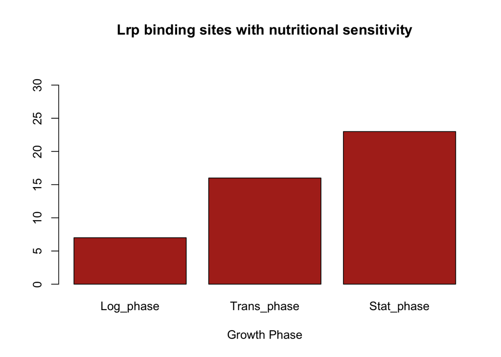

```r
sensitive_sites <- data.frame(col1=count(filter(media_sensitivity,media_sensitivity$Change_log=="Present")),col2=count(filter(media_sensitivity,media_sensitivity$Change_trans=="Present")),col3=count(filter(media_sensitivity,media_sensitivity$Change_stat=="Present")))

colnames(sensitive_sites) <- c("Log_phase","Trans_phase","Stat_phase")

sensitive_sites <- as.matrix(sensitive_sites)

Site_nutrient_sens <- barplot(sensitive_sites,main="Lrp binding sites with nutritional sensitivity", xlab="Growth Phase",ylim=c(0,34), col="#B02D1F")
```

Se guardan las dos gráficas generadas como “ChIPseq_data_graphs.Rdata”

save(Temporal_Lrp_variation,Site_nutrient_sens,file=“ChIPseq_data_graphs.Rdata”)

### Resumen de información obtenida

Se utilizaron datos de un experimento de ChIP-seq evaluando los sitios de unión al factor de transcripción Lrp en *E. coli*. Estos datos se obtuvieron de muestras tomadas en tres fases del crecimiento bacteriano, de colonias expuestas a tres distintas condiciones nutricionales del medio, posteriormente, se depositaron en RegulonDB. Para este proyecto, principalmente se prestó atención en la información depositada en los archivos *sites.bed que contienen los sitios de unión posterior al procesamiento del algoritmo “peak calling” en cada una de las condiciones de crecimiento/nutrientes. A través del procesamiento de datos utilizando la línea de comandos en bash, así como RStudio, se pudo llegar a las siguientes conclusiones:

1. Se identificaron 34 sitios de unión distintos en las nueve condiciones.
2. La unión de 28 de estos sitios (82%) a Lrp cambiaba de acuerdo con la fase de crecimiento y/o las condiciones nutricionales.
3. La exposición a medio con nutrientes mínimos presentó un incremento en los sitios del genoma unidos a Lrp a lo largo del crecimiento.
4. La exposición a medio enriquecido tuvo una disminución en los sitios unidos a Lrp al pasar a la fase estacionaria.
5. La fase estacionaria de bacterias en medio mínimo alcanzó el máximo número de sitos unidos a Lrp, comparada con el resto de condiciones.
6. Hubo un incremento en la variabilidad de cada sitio de unión a Lrp atribuida a los nutrientes del medio de acuerdo con la fase de crecimiento (log<trans<stat). Alcanzando unión diferencial a Lrp en 23 sitios durante la fase estacionaria.

**Lo que seguiría en el algoritmo de procesamiento de estos datos, es la comparación de los sitios encontrados con los previamente reportados, y asociarlos a los genes correspondientes. De esta manera se podría realizar un análisis ontológico para determinar vías de señalización y actividad celular que respondieran de forma diferente a Lrp de acuerdo con las características nutricionales del medio.**